# 1.2 Discrete statistical distributions

17/01/2024

## Bernoulli distribution

Tossing a coin

```r
rbern(1, p=0.5)
```

```
## [1] 1
```

## Bernoulli distribution

The coin is biased

```r
rbern(1, p=0.7)
```

```
## [1] 1
```

## Bernoulli distribution

Tossing a coin multiple times

```r
bern=rbern(100, p=0.7)
bern
```

```
##   [1] 0 1 0 1 1 1 1 0 1 1 1 1 1 0 1 0 1 1 0 1 1 0 0 1 1 0 1 1 1 0 0 1 0 1 1 1 0
##  [38] 0 1 1 0 1 0 0 1 1 0 1 0 1 0 1 1 1 0 1 1 1 1 0 1 0 1 1 1 1 1 1 0 1 1 1 0 0
##  [75] 0 1 1 1 1 1 0 1 1 1 1 1 1 1 0 1 1 1 1 1 0 1 0 1 1 1
```

## Bernoulli distribution

The mean expected result equals to p

```r
mean(bern)
```

```
## [1] 0.69
```

## Bernoulli distribution

The mean result equals to p

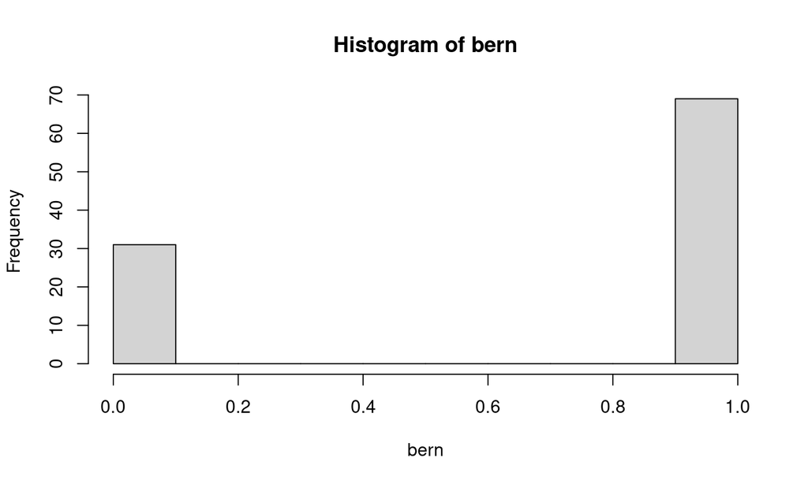

```r
hist(bern)
```

## Bernoulli distribution

Application: Did my experimental seed germinate?

## Binomial distribution

I toss a coin multiple times and I am interested in the sum of results

```r
rbinom(1, size=10, p=0.7)
```

```
## [1] 6
```

```r
binom=rbinom(100, size=10, p=0.7)
binom
```

```
##   [1]  6  8  9  6  8  6  6  6  7  8  8  8  4  5  7  8  9  5  5  8  6  6  7 10  8
##  [26]  7  7  7  7  6  6 10  5  8  7  4  9  7  5  8  8  9  8  8  9  8  9  8  6  5
##  [51]  4  7 10  5  7  6  7  4  9  9  7  9  8  9  6  8  4  6  5  7  5  6  7  5  6
##  [76]  7  6  8  5  8  6  7  9  8  5 10  7  6  6  9  9  5  4  8  9  6  7  8  7  7
```

## Binomial distribution

The mean expected result equals to size*p

```r
10*0.7
```

```
## [1] 7
```

```r
mean(binom)
```

```
## [1] 6.98
```

## Binomial distribution

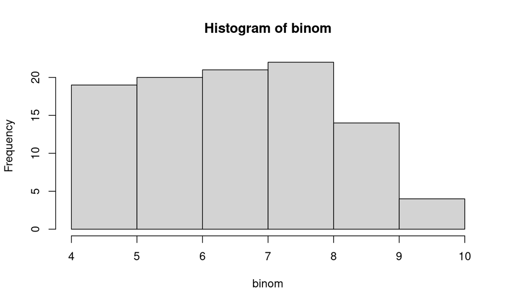

```r
hist(binom)
```

## Binomial distribution

Application: I have sown 100 seeds. How many of them germinated?

## Exercise 1

Simulate a sample from a binomial distribution of size=20 and p=0.3 using only rbern() function.

## Exercise 1

```r
ex1=rbern(20, 0.3)
sum(ex1)
```

```
## [1] 6
```

## Poisson distribution

I toss a coin \(\infty\) times. The mean expected result is size*p. But the size is \(\infty\)

\(\infty\) * p = \(\infty\) for any p>0

\(\infty\) * 0 = \(\lambda\) , where \(\lambda\)>0

-> lets use \(\lambda\) for controlling the distribution, rather than p

```r
pois=rpois(100, lambda=4)
pois
```

```
##   [1]  5  4  8  5  2  1  6  4  8  4  3  4  4  4  6  0  6  2  6  4  2  5  3  1  4
##  [26]  4  2  1  2  3  6  0  4  2 10  2  8  6  4  2  8  1  3  3  6  1  5  2  7  3
##  [51]  3  4  2  5  2  5  6  3  1  4  2  4  4  3  3  4  2  3  5  2  3  4  3  5  5
##  [76]  4  5  5  1  8  9  3  4  8  7  3  5  4  3  2  4  5  5  2  4  3  4  5  3  6
```

## Poisson distribution

The mean expected result equals to \(\lambda\)

```r
mean(pois)
```

```
## [1] 3.95
```

… of course that’s how we defined \(\lambda\)

## Poisson distribution

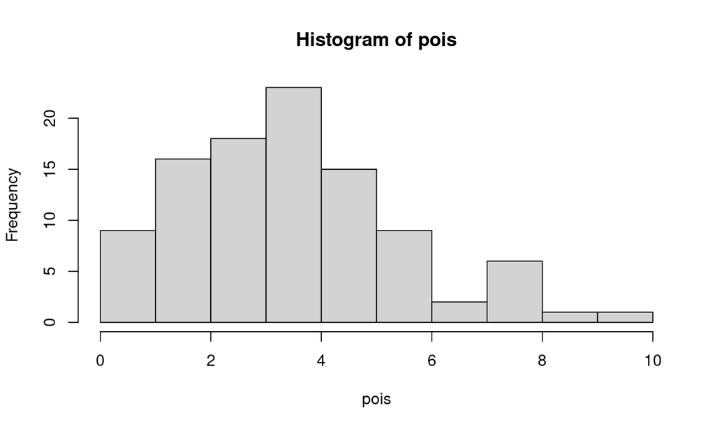

```r
hist(pois)
```

## Poisson distribution

Application: How many pollinators visited the observed plant? The number of potential visitors is theoretically unlimited.

## Exercise 2

Simulate 1000 samples from a distribution that is reasonably close to Poisson with \(\lambda\)=3, using only rbinom() function.

## Exercise 2

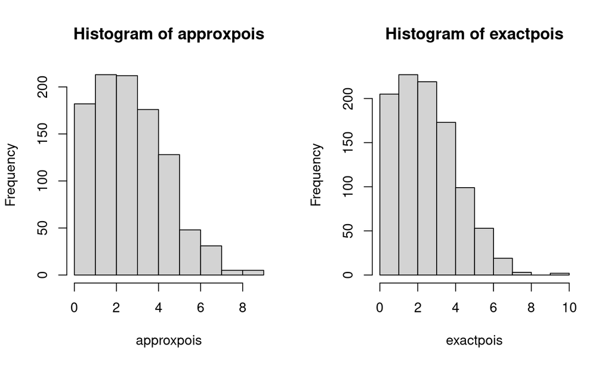

```r
approxpois=rbinom(1000, size=3000000, p=0.000001)
exactpois=rpois(1000, lambda = 3)
par(mfrow=c(1,2)); hist(approxpois); hist(exactpois)
```

```r
par(mfrow=c(1,1))
```